# Identifying Gender Based on Voice in Telephone Recording Using Machine Learning

Fitra Kacamarga

October 16, 2018

# 1 Introduction

- [The Harvard-Haskins Database of Regularly-Timed Speech](http://www.nsi.edu/~ani/download.html)
- [Telecommunications & Signal Processing Laboratory (TSP) Speech Database at McGill University](http://www-mmsp.ece.mcgill.ca/Documents../Data/index.html)
- [VoxForge Speech Corpus](http://www.repository.voxforge1.org/downloads/SpeechCorpus/Trunk/Audio/Main/8kHz_16bit/)
- [Festvox CMU_ARCTIC Speech Database at Carnegie Mellon University](http://festvox.org/cmu_arctic/)

# 2 Feature Extraction

The frequency 0 hz-280 hz with a sound threshold of 15 % are used for acoustic properties extraction. The following acoustic properties of each voice are measured (Becker,2016):

- **meanfreq:** mean frequency (in kHz)
- **sd:** standard deviation of frequency
- **median:** median frequency (in kHz)
- **Q25:** first quantile (in kHz)
- **Q75:** third quantile (in kHz)
- **IQR:** interquantile range (in kHz)
- **skew:** skewness (see note in specprop description)
- **kurt:** kurtosis (see note in specprop description)
- **sp.ent:** spectral entropy
- **sfm:** spectral flatness
- **mode:** mode frequency
- **centroid:** frequency centroid (see specprop)
- **peakf:** peak frequency (frequency with highest energy)
- **meanfun:** average of fundamental frequency measured across acoustic signal
- **minfun:** minimum fundamental frequency measured across acoustic signal
- **maxfun:** maximum fundamental frequency measured across acoustic signal
- **meandom:** average of dominant frequency measured across acoustic signal
- **mindom:** minimum of dominant frequency measured across acoustic signal
- **maxdom:** maximum of dominant frequency measured across acoustic signal
- **dfrange:** range of dominant frequency measured across acoustic signal
- **modindx:** modulation index. Calculated as the accumulated absolute difference between adjacent measurements of fundamental frequencies divided by the frequency range

Each sounds are labeled male or female.

# 3 Exploratory Data Analysis

## 3.1 Top rows of the data

```
##      meanfreq         sd     median         Q25        Q75        IQR
## 1  0.05978098 0.06424127 0.03202691 0.015071489 0.09019344 0.07512195
## 2  0.06600874 0.06731003 0.04022873 0.019413867 0.09266619 0.07325232
## 3  0.07731550 0.08382942 0.03671846 0.008701057 0.13190802 0.12320696
## 4  0.15122809 0.07211059 0.15801119 0.096581728 0.20795525 0.11137352
## 5  0.13512039 0.07914610 0.12465623 0.078720218 0.20604493 0.12732471
## 6  0.13278641 0.07955687 0.11908985 0.067957993 0.20959160 0.14163361
## 7  0.15076233 0.07446321 0.16010638 0.092898936 0.20571809 0.11281915
## 8  0.16051433 0.07676688 0.14433678 0.110532168 0.23196187 0.12142971
## 9  0.14223942 0.07801846 0.13858744 0.088206278 0.20858744 0.12038117
## 10 0.13432878 0.08035003 0.12145135 0.075579989 0.20195712 0.12637713
##         skew        kurt    sp.ent       sfm       mode   centroid
## 1  12.863462  274.402906 0.8933694 0.4919178 0.00000000 0.05978098
## 2  22.423285  634.613855 0.8921932 0.5137238 0.00000000 0.06600874
## 3  30.757155 1024.927705 0.8463891 0.4789050 0.00000000 0.07731550
```

[output cut: 29 more lines]

## 3.2 Dimensions of the data (rows, columns)

```
##   number of rows number of columns
## 1           3168                21
```

## 3.3 Names and types of columns

```
## 'data.frame':    3168 obs. of  21 variables:
##  $ meanfreq: num  0.0598 0.066 0.0773 0.1512 0.1351 ...
##  $ sd      : num  0.0642 0.0673 0.0838 0.0721 0.0791 ...
##  $ median  : num  0.032 0.0402 0.0367 0.158 0.1247 ...
##  $ Q25     : num  0.0151 0.0194 0.0087 0.0966 0.0787 ...
##  $ Q75     : num  0.0902 0.0927 0.1319 0.208 0.206 ...
##  $ IQR     : num  0.0751 0.0733 0.1232 0.1114 0.1273 ...
##  $ skew    : num  12.86 22.42 30.76 1.23 1.1 ...
##  $ kurt    : num  274.4 634.61 1024.93 4.18 4.33 ...
##  $ sp.ent  : num  0.893 0.892 0.846 0.963 0.972 ...
##  $ sfm     : num  0.492 0.514 0.479 0.727 0.784 ...
##  $ mode    : num  0 0 0 0.0839 0.1043 ...
##  $ centroid: num  0.0598 0.066 0.0773 0.1512 0.1351 ...
##  $ meanfun : num  0.0843 0.1079 0.0987 0.089 0.1064 ...
##  $ minfun  : num  0.0157 0.0158 0.0157 0.0178 0.0169 ...
##  $ maxfun  : num  0.276 0.25 0.271 0.25 0.267 ...
##  $ meandom : num  0.00781 0.00901 0.00799 0.2015 0.71281 ...
##  $ mindom  : num  0.00781 0.00781 0.00781 0.00781 0.00781 ...
##  $ maxdom  : num  0.00781 0.05469 0.01562 0.5625 5.48438 ...
##  $ dfrange : num  0 0.04688 0.00781 0.55469 5.47656 ...
##  $ modindx : num  0 0.0526 0.0465 0.2471 0.2083 ...
##  $ label   : Factor w/ 2 levels "female","male": 2 2 2 2 2 2 2 2 2 2 ...
```

## 3.4 Summarise data

```
##     meanfreq             sd              median             Q25
##  Min.   :0.03936   Min.   :0.01836   Min.   :0.01097   Min.   :0.0002288
##  1st Qu.:0.16366   1st Qu.:0.04195   1st Qu.:0.16959   1st Qu.:0.1110865
##  Median :0.18484   Median :0.05916   Median :0.19003   Median :0.1402864
##  Mean   :0.18091   Mean   :0.05713   Mean   :0.18562   Mean   :0.1404556
##  3rd Qu.:0.19915   3rd Qu.:0.06702   3rd Qu.:0.21062   3rd Qu.:0.1759388
##  Max.   :0.25112   Max.   :0.11527   Max.   :0.26122   Max.   :0.2473469
##       Q75               IQR               skew              kurt
##  Min.   :0.04295   Min.   :0.01456   Min.   : 0.1417   Min.   :   2.068
##  1st Qu.:0.20875   1st Qu.:0.04256   1st Qu.: 1.6496   1st Qu.:   5.670
##  Median :0.22568   Median :0.09428   Median : 2.1971   Median :   8.319
##  Mean   :0.22476   Mean   :0.08431   Mean   : 3.1402   Mean   :  36.569
##  3rd Qu.:0.24366   3rd Qu.:0.11418   3rd Qu.: 2.9317   3rd Qu.:  13.649
##  Max.   :0.27347   Max.   :0.25223   Max.   :34.7255   Max.   :1309.613
##      sp.ent            sfm               mode           centroid
##  Min.   :0.7387   Min.   :0.03688   Min.   :0.0000   Min.   :0.03936
##  1st Qu.:0.8618   1st Qu.:0.25804   1st Qu.:0.1180   1st Qu.:0.16366
##  Median :0.9018   Median :0.39634   Median :0.1866   Median :0.18484
##  Mean   :0.8951   Mean   :0.40822   Mean   :0.1653   Mean   :0.18091
##  3rd Qu.:0.9287   3rd Qu.:0.53368   3rd Qu.:0.2211   3rd Qu.:0.19915
##  Max.   :0.9820   Max.   :0.84294   Max.   :0.2800   Max.   :0.25112
##     meanfun            minfun             maxfun          meandom
##  Min.   :0.05557   Min.   :0.009775   Min.   :0.1031   Min.   :0.007812
##  1st Qu.:0.11700   1st Qu.:0.018223   1st Qu.:0.2540   1st Qu.:0.419828
##  Median :0.14052   Median :0.046110   Median :0.2712   Median :0.765795
##  Mean   :0.14281   Mean   :0.036802   Mean   :0.2588   Mean   :0.829211
##  3rd Qu.:0.16958   3rd Qu.:0.047904   3rd Qu.:0.2775   3rd Qu.:1.177166
##  Max.   :0.23764   Max.   :0.204082   Max.   :0.2791   Max.   :2.957682
##      mindom             maxdom             dfrange          modindx
##  Min.   :0.004883   Min.   : 0.007812   Min.   : 0.000   Min.   :0.00000
##  1st Qu.:0.007812   1st Qu.: 2.070312   1st Qu.: 2.045   1st Qu.:0.09977
##  Median :0.023438   Median : 4.992188   Median : 4.945   Median :0.13936
##  Mean   :0.052647   Mean   : 5.047277   Mean   : 4.995   Mean   :0.17375
##  3rd Qu.:0.070312   3rd Qu.: 7.007812   3rd Qu.: 6.992   3rd Qu.:0.20918
##  Max.   :0.458984   Max.   :21.867188   Max.   :21.844   Max.   :0.93237
##     label
##  female:1584
##  male  :1584
##
##
##
##
```

## 3.6 Visual gender vs attributes

```
## $meanfreq
##
##  Welch Two Sample t-test
##
## data:  x by data$label
## t = 20.168, df = 3112.4, p-value < 2.2e-16
## alternative hypothesis: true difference in means is not equal to 0
## 95 percent confidence interval:
##  0.01822375 0.02214873
## sample estimates:
## mean in group female   mean in group male
##            0.1909997            0.1708135
##
##
## $sd
##
##  Welch Two Sample t-test
##
## data:  x by data$label
## t = -30.748, df = 2365.9, p-value < 2.2e-16
## alternative hypothesis: true difference in means is not equal to 0
## 95 percent confidence interval:
##  -0.01698665 -0.01494991
## sample estimates:
## mean in group female   mean in group male
##           0.04914183           0.06511010
##
##
## $median
##
##  Welch Two Sample t-test
##
## data:  x by data$label
## t = 16.661, df = 3096.4, p-value < 2.2e-16
## alternative hypothesis: true difference in means is not equal to 0
## 95 percent confidence interval:
##  0.01821403 0.02307284
## sample estimates:
## mean in group female   mean in group male
##            0.1959424            0.1752990
```

[output cut: 223 more lines]

```
##             5.671120             4.318139
##
##
## $modindx
##
##  Welch Two Sample t-test
##
## data:  x by data$label
## t = -1.7339, df = 3058.5, p-value = 0.08303
## alternative hypothesis: true difference in means is not equal to 0
## 95 percent confidence interval:
##  -0.0156774460  0.0009625026
## sample estimates:
## mean in group female   mean in group male
##            0.1700728            0.1774302
```

This step we’re find interaction between gender with variables. Only modindx considered not statistical significance with alpha 0.05.

## 3.7 Correlation between variables

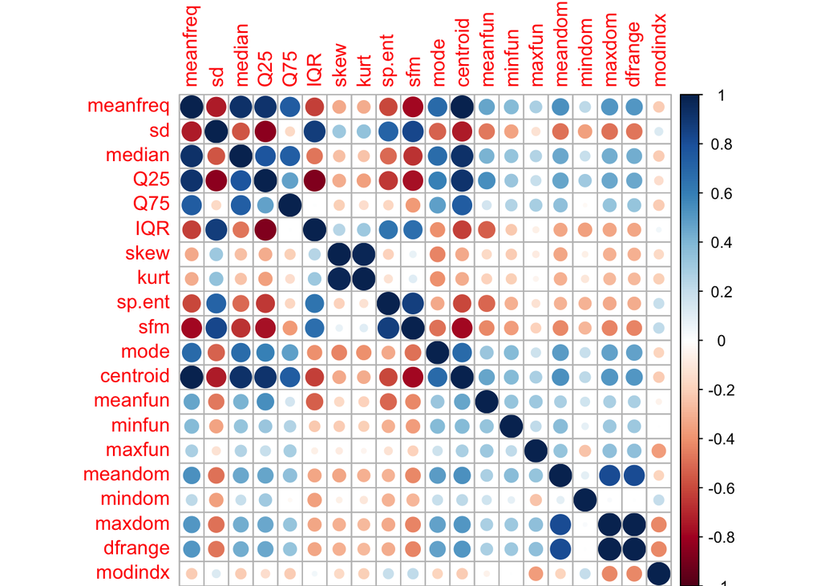

```
## [1] "meanfreq" "centroid" "maxdom"   "kurt"
```

meanfreq, centroid, maxdom and kurt are considered highly correlated with other variables.

# 4 Features Selection

Features selection often increases accuracy by eliminating irrelevant, redundant or highly correlated variables. In this article, we used pearson correlation to find correlation between features and recrusive feature elimination (rfe) for features selection. We also test whether features selection method improved our model or not.

## 4.1 Filter out highly correlated features

```
## [1] "meanfreq" "centroid" "maxdom"   "kurt"
```

Above list features are considered highly correlate with other variables

## 4.2 Selecting variables based on recrusive feature elimination method

In this step we’re used cross validation with k-fold = 10. This is list of variables which are important.

```
##  [1] "meanfun" "IQR"     "Q25"     "sd"      "sfm"     "Q75"     "sp.ent"
##  [8] "modindx" "maxdom"  "minfun"  "median"
```

Lets find is it data with selected features perform better than baseline (without features selection). We’re used Generalized Linear Model (GLM) model for measured the performance of the features selection methods.

```
##   alpha       lambda       ROC      Sens      Spec       ROCSD     SensSD
## 1   0.1 0.0008342295 0.9932293 0.9676478 0.9787152 0.004219816 0.01984284
##      SpecSD
## 1 0.0166181
```

By removing correlated we got ROC 0.9932293 in training data.

```
## Confusion Matrix and Statistics
##
##           Reference
## Prediction female male
##     female    302    6
##     male       14  310
##
##                Accuracy : 0.9684
##                  95% CI : (0.9515, 0.9806)
##     No Information Rate : 0.5
##     P-Value [Acc > NIR] : <2e-16
##
##                   Kappa : 0.9367
##  Mcnemar's Test P-Value : 0.1175
##
##             Sensitivity : 0.9557
##             Specificity : 0.9810
##          Pos Pred Value : 0.9805
##          Neg Pred Value : 0.9568
##              Prevalence : 0.5000
##          Detection Rate : 0.4778
##    Detection Prevalence : 0.4873
##       Balanced Accuracy : 0.9684
##
##        'Positive' Class : female
##
```

In the test data we got accuracy 0.9683544 and kappa 0.9367089

```
##   alpha       lambda      ROC    Sens      Spec       ROCSD     SensSD
## 1   0.1 0.0008318181 0.993382 0.97006 0.9763092 0.004724893 0.01846596
##       SpecSD
## 1 0.01631498
```

By using RFE we got ROC 0.993382

```
## Confusion Matrix and Statistics
##
##           Reference
## Prediction female male
##     female    306    9
##     male       10  307
##
##                Accuracy : 0.9699
##                  95% CI : (0.9534, 0.9818)
##     No Information Rate : 0.5
##     P-Value [Acc > NIR] : <2e-16
##
##                   Kappa : 0.9399
##  Mcnemar's Test P-Value : 1
##
##             Sensitivity : 0.9684
##             Specificity : 0.9715
##          Pos Pred Value : 0.9714
##          Neg Pred Value : 0.9685
##              Prevalence : 0.5000
##          Detection Rate : 0.4842
##    Detection Prevalence : 0.4984
##       Balanced Accuracy : 0.9699
##
##        'Positive' Class : female
##
```

In the test data we got accuracy 0.9699367 and kappa 0.9398734 which are not so different with the features from removing correlated features.

```
##   alpha       lambda      ROC      Sens      Spec       ROCSD     SensSD
## 1   0.1 0.0008325846 0.993613 0.9653106 0.9771466 0.003351909 0.01824274
##      SpecSD
## 1 0.0130817
```

```
## Confusion Matrix and Statistics
##
##           Reference
## Prediction female male
##     female    304    7
##     male       12  309
##
##                Accuracy : 0.9699
##                  95% CI : (0.9534, 0.9818)
##     No Information Rate : 0.5
##     P-Value [Acc > NIR] : <2e-16
##
##                   Kappa : 0.9399
##  Mcnemar's Test P-Value : 0.3588
##
##             Sensitivity : 0.9620
##             Specificity : 0.9778
##          Pos Pred Value : 0.9775
##          Neg Pred Value : 0.9626
##              Prevalence : 0.5000
##          Detection Rate : 0.4810
##    Detection Prevalence : 0.4921
##       Balanced Accuracy : 0.9699
##
##        'Positive' Class : female
##
```

# 5 Model training

## 5.1 Defining Hyperparameter sets

In this article, we’re used generalized linear model, random forest, Xgboost and Stochastic Gradient Boostings. To define the best hyperparameter sets, Here we used OneSE (One Standard Error) as selection function and repeated cross validation with 10 k-folds are used for hyperparameter sweeping. We choose 60 point random grid sample for grid search.

## 5.2 Train Random Forest with parameter sweeping:

```
## Confusion Matrix and Statistics
##
##           Reference
## Prediction female male
##     female    310    6
##     male        6  310
##
##                Accuracy : 0.981
##                  95% CI : (0.9671, 0.9902)
##     No Information Rate : 0.5
##     P-Value [Acc > NIR] : <2e-16
##
##                   Kappa : 0.962
##  Mcnemar's Test P-Value : 1
##
##             Sensitivity : 0.9810
##             Specificity : 0.9810
##          Pos Pred Value : 0.9810
##          Neg Pred Value : 0.9810
##              Prevalence : 0.5000
##          Detection Rate : 0.4905
##    Detection Prevalence : 0.5000
##       Balanced Accuracy : 0.9810
##
##        'Positive' Class : female
##
```

## 5.3 Train Xgboost with parameter sweeping:

```
## Confusion Matrix and Statistics
##
##           Reference
## Prediction female male
##     female    314    5
##     male        2  311
##
##                Accuracy : 0.9889
##                  95% CI : (0.9773, 0.9955)
##     No Information Rate : 0.5
##     P-Value [Acc > NIR] : <2e-16
##
##                   Kappa : 0.9778
##  Mcnemar's Test P-Value : 0.4497
##
##             Sensitivity : 0.9937
##             Specificity : 0.9842
##          Pos Pred Value : 0.9843
##          Neg Pred Value : 0.9936
##              Prevalence : 0.5000
##          Detection Rate : 0.4968
##    Detection Prevalence : 0.5047
##       Balanced Accuracy : 0.9889
##
##        'Positive' Class : female
##
```

## 5.4 Train Stochastic Gradient Boostings with parameter sweeping:

```
## Confusion Matrix and Statistics
##
##           Reference
## Prediction female male
##     female    315    2
##     male        1  314
##
##                Accuracy : 0.9953
##                  95% CI : (0.9862, 0.999)
##     No Information Rate : 0.5
##     P-Value [Acc > NIR] : <2e-16
##
##                   Kappa : 0.9905
##  Mcnemar's Test P-Value : 1
##
##             Sensitivity : 0.9968
##             Specificity : 0.9937
##          Pos Pred Value : 0.9937
##          Neg Pred Value : 0.9968
##              Prevalence : 0.5000
##          Detection Rate : 0.4984
##    Detection Prevalence : 0.5016
##       Balanced Accuracy : 0.9953
##
##        'Positive' Class : female
##
```

# 6 Model evaluations: Compare model performance and examine variable importance

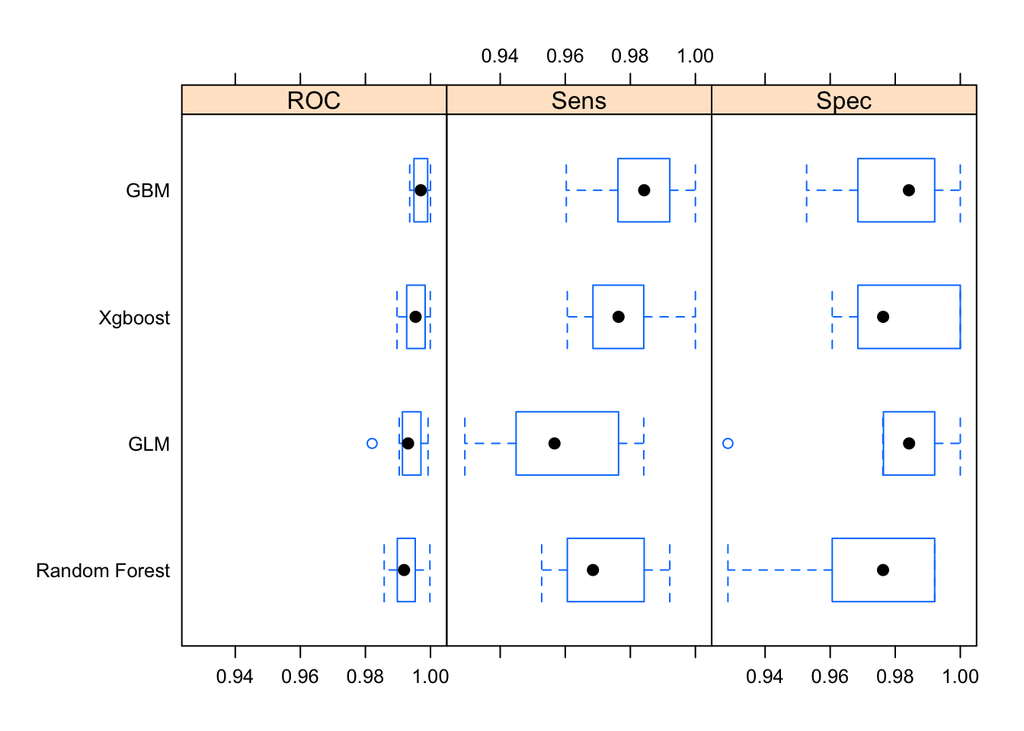

```r
summary(modelCompared)
```

```
##
## Call:
## summary.resamples(object = modelCompared)
##
## Models: GLM, Random Forest, Xgboost, GBM
## Number of resamples: 10
##
## ROC
##                 Min. 1st Qu. Median   Mean 3rd Qu.   Max. NA's
## GLM           0.9821  0.9916 0.9931 0.9931  0.9966 0.9993    0
## Random Forest 0.9858  0.9899 0.9919 0.9925  0.9946 0.9998    0
## Xgboost       0.9897  0.9927 0.9954 0.9952  0.9982 0.9999    0
## GBM           0.9936  0.9950 0.9970 0.9970  0.9991 1.0000    0
##
## Sens
##                 Min. 1st Qu. Median   Mean 3rd Qu.   Max. NA's
## GLM           0.9291  0.9449 0.9567 0.9590  0.9763 0.9841    0
## Random Forest 0.9528  0.9625 0.9685 0.9708  0.9803 0.9921    0
## Xgboost       0.9606  0.9705 0.9764 0.9779  0.9822 1.0000    0
## GBM           0.9603  0.9762 0.9843 0.9818  0.9902 1.0000    0
##
## Spec
##                 Min. 1st Qu. Median   Mean 3rd Qu.   Max. NA's
## GLM           0.9286  0.9764 0.9843 0.9795  0.9902 1.0000    0
## Random Forest 0.9286  0.9606 0.9763 0.9716  0.9902 0.9921    0
## Xgboost       0.9606  0.9685 0.9763 0.9803  0.9980 1.0000    0
## GBM           0.9528  0.9705 0.9842 0.9803  0.9921 1.0000    0
```

## 6.2 Visualize ROC curve of actual vs predicted.

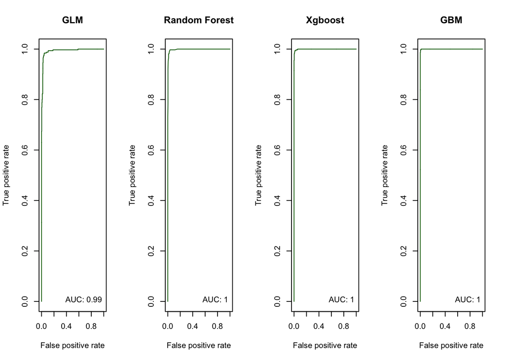

From figure above, we can see most models produced perfect score (AUC = 1) for classifying gender in the training data.

## 6.3 Variable importance: Plot top 10 relative variable importances for different models

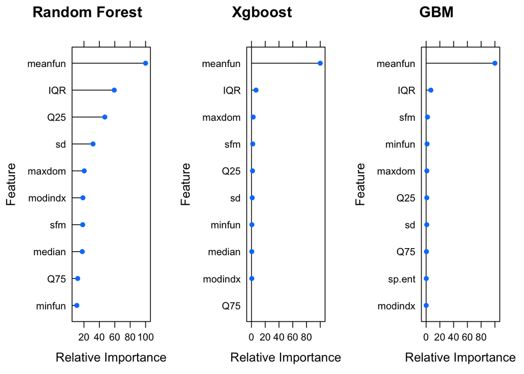

Meanfun and IQR are most important variables from three models. In the next step we’re going to implement the models for detecting voice gender in the telephone recording.

# 7 Implementation of predicting voice gender in the telephone recording

Flow of the process as follow:

Audio => Speech diarization => Extract acoustic parameters => Predict Gender

## 7.1 Audio format

The audio format used this implementation is WAVE format with 16,000 sample rate. All audio will converted with respectively format. We used ffmpeg tool for this task.

## 7.2 Speaker diarisation

According Wikipedia, speaker diarisation is the process of partitioning an input audio stream into homogeneous segments according to the speaker identity. The main objective is to answer the question “who spoke when?”. In our case, we use speech diarization for annotating regions (in this case, time) of speaker speech in telephone conversation. We used Aalto ASR tool for speaker diarisation (https://github.com/aalto-speech/speaker-diarization). We used Bayesian Information Criterion (BIC) with lambda 0.75 for detecting speaker turn and Generalized Likelihood Ration (GLR) with 1000 iteration threshold for detecting speaker clustering.

The output of speech diarization for file test_1:

```
## [1] "audio=wav/test_1.wav lna=a_1 start-time=1.056 end-time=114.904 speaker=speaker_1"
## [2] "audio=wav/test_1.wav lna=a_2 start-time=114.904 end-time=116.264 speaker=speaker_2"
```

## 7.3 Extract accoustic parameters

Extracted acoustic parameter for file test_1:

```
##      cst str_time fin_time     spker  meanfreq         sd    median
## 1 test_1    1.056  114.904 speaker_1 0.2291501 0.04481579 0.2397603
## 2 test_1  114.904  116.264 speaker_2 0.1671765 0.07262566 0.1750923
##         Q25       Q75        IQR     skew     kurt    sp.ent       sfm
## 1 0.2140758 0.2590676 0.04499184 1.991547 6.647892 0.9133761 0.2861728
## 2 0.1078628 0.2305013 0.12263852 1.073947 4.577159 0.9604643 0.7481796
##        mode  centroid peakf    meanfun     minfun    maxfun   meandom
## 1 0.2549040 0.2291501     0 0.20825011 0.01564027 0.2758621 0.6847936
## 2 0.2090765 0.1671765     0 0.09612084 0.01606426 0.2388060 1.2382812
##     mindom   maxdom  dfrange    modindx
## 1 0.000000 6.117188 6.117188 0.05509837
## 2 0.703125 2.132812 1.429688 0.52155434
```

## 7.4 Predict gender

Prediction output for test_1:

```
##   subscriber spk1_pred_male spk1_pred_female spk2_pred_male
## 2     test_1           0.55             0.45              0
##   spk2_pred_female gender_spk1 gender_spk2
## 2                1        male      female
```

# 8 Conclusion

# 9 Reference

- Becker, K. (2016). Identifying the Gender of a Voice using Machine Learning. Retrieved from http://www.primaryobjects.com/2016/06/22/identifying-the-gender-of-a-voice-using-machine-learning/